# Linear Regression

Dorothee Mersch

8 Juli 2019

# Linear Regresssion Analysis

## Used Library:

```r
library(reshape)
library(ggplot2)
```

## Data adjustment

In oder to create a vector, which contains all IC50 values per cell line, the melt function was used. Afterwards NAs of this vector were removed. Than celllines, which were included in the vector, but not in the RGES result data were deleted. Finally a new matrix of the RGES results and IC50 values was created and saved as drug_activity_rges.

```r
# Create vector IC50 values
ic50 = t(ic50)
melt.data <- melt(ic50)
melt.data = as.matrix(melt.data)
melt.ic50 = as.data.frame(melt.data)
colnames(melt.ic50) = c("cell", "drug", "IC50")

# Remove NAs
rmv.rows = apply(melt.data, 1, function(x) {
  sum(is.na(x))
})
which(rmv.rows > 0)
melt.ic50 = melt.data[-which(rmv.rows > 0),]
rm(melt.data)

# Adjust cell lines of IC50 vector
IC50.value = c(rep(as.numeric(0),819))
results = cbind(results, IC50.value)

i=1
j=1

while(i<895)
{while(j<820)
{
  if(isTRUE(melt.ic50[i,1]== results[j,4])
     & (melt.ic50[i,2] == results[j,5]))
  {results[j,9] = as.numeric(melt.ic50[i,3])
  }
  j = j +1
}
  j= 1
  i=i+1}

which(results$IC50.value == 0)

# Define new matrix
drug_activity_rges = results[-which(results$IC50.value == 0),]
```

## 1. Univariate Regression: IC50 - RGES

### 1.2. Variable RGES

First the data set was limited to numerical values. A data frame with RGES and IC50 values is obtained.

### 1.2.1 Correlation IC50 - RGES

As a next step the correlation between the computed RGES values and the IC50 values is checked. The spearman method was used as it is less prone to outliers.

Rho IC50 - RGES:

```r
cor(rges.ic50$RGES, rges.ic50$IC50.value, method = "spearman")
```

```
## [1] -0.05689886
```

Result of significance check:

```
##
##  Spearman's rank correlation rho
##
## data:  rges.ic50$RGES and rges.ic50$IC50.value
## S = 94308000, p-value = 0.1052
## alternative hypothesis: true rho is not equal to 0
## sample estimates:
##         rho
## -0.05689886
```

RGES values can also be plotted against IC50 values in order to visualize the correlation.

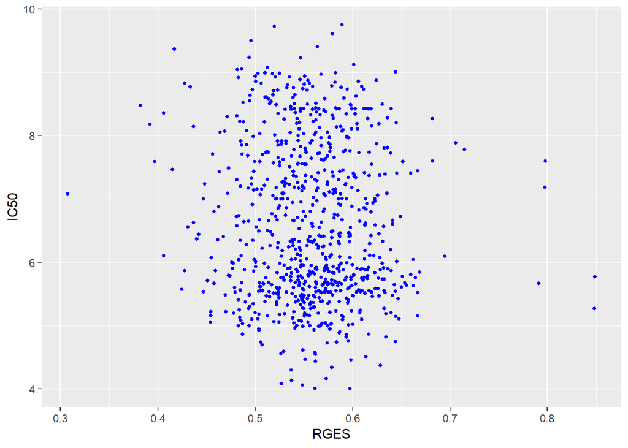

**Discussion** The correlation coefficient as well as the plot of RGES values against the IC50 values are not really convincing. A possible reason could be, that the RGES values illustrate the drugs potentcy to reverse the cancer induced gene expression. Most of the analysed drugs are chemotherapy agents and do not interact with gene expression. Nevertheless it will be tried to compute a linear regression model and predict the IC50 values with the previously computed RGES values.

### 1.2.2 Computation univariate model

The linear regression model should be learned on a training set. The training set is formed by 730 random variables of the data set (correspond to ~90 % of the whole data set). The other part of the data set than is called test set. It was checked, whether the residuals are normal distributed and whether they correlate with x-values.

```r
i.train = sample(1:nrow(rges.ic50), 730)

rges.ic50.train = rges.ic50[i.train, ]
rges.ic50.test = rges.ic50[-i.train, ]
```

### 1.2.3 Result univariate model: IC50 - RGES:

```r
lm.rges_ic50 = lm(IC50.value ~ RGES, data = rges.ic50.train)
```

```
##
## Call:
## lm(formula = IC50.value ~ RGES, data = rges.ic50.train)
##
## Residuals:
##     Min      1Q  Median      3Q     Max
## -2.5945 -0.9893 -0.2564  0.9867  3.0412
##
## Coefficients:
##             Estimate Std. Error t value Pr(>|t|)
## (Intercept)   7.7095     0.4606   16.74   <2e-16 ***
## RGES         -1.9669     0.8229   -2.39   0.0171 *
## ---
## Signif. codes:  0 '***' 0.001 '**' 0.01 '*' 0.05 '.' 0.1 ' ' 1
##
## Residual standard error: 1.227 on 728 degrees of freedom
## Multiple R-squared:  0.007787,   Adjusted R-squared:  0.006424
## F-statistic: 5.713 on 1 and 728 DF,  p-value: 0.01709
```

**Discussion** Interpreting the output, the R squared value shows, that less than one percent of of the variance can be explained by the model. In contrast, the F-statistic suggest, that the model is at least better than taking the mean of the drug sensitivity values. Also the p-value shows, that the intercept could not be 0. In summary, the model does not convince at all as only a small amount of the variance can be explained.

To analyze the residuals, they can be plotted against the fitted values. A normal Quantile-Quantile plot was performed, in order to check the normal distribution of the residuals.

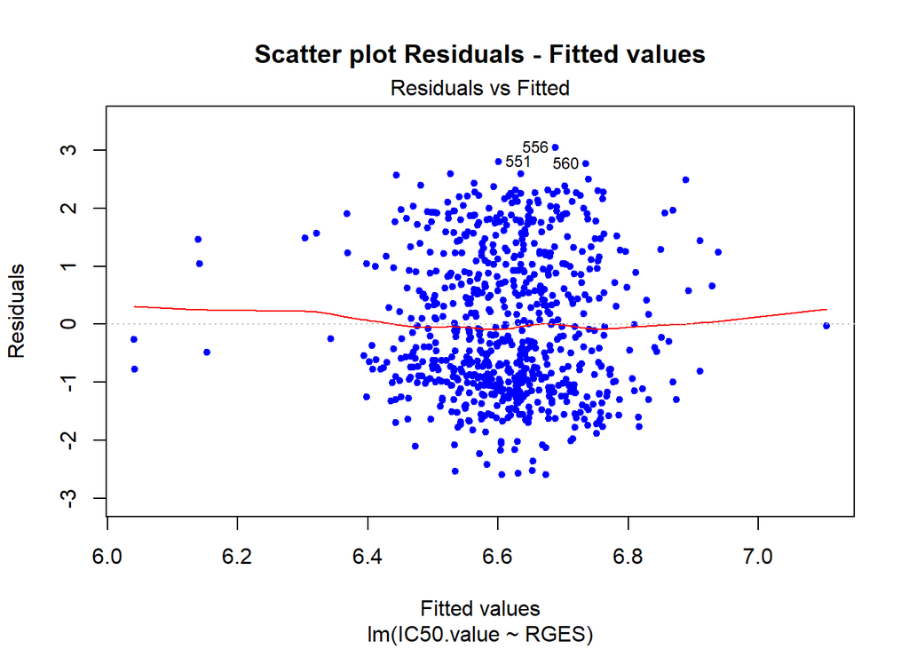

```r
plot(lm.rges_ic50, which = c(1), pch=20, col="blue", main = "Scatter plot Residuals - Fitted values")
```

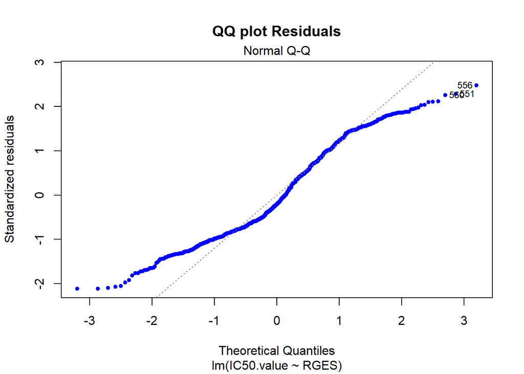

```r
plot(lm.rges_ic50, which = c(2), pch=20, col="blue", main = "QQ plot Residuals")
```

To check, that the residuals do not correlate with x, the correlation between RGES and residuals is computed. Correlation coefficient Residuals - RGES:

```r
cor(rges.ic50.train$RGES, lm.rges_ic50$residuals)
```

```
## [1] 1.154698e-17
```

The low value can be interpreted as no correlation between RGES and residuals.

### 1.2.4. Prediction of IC50 data

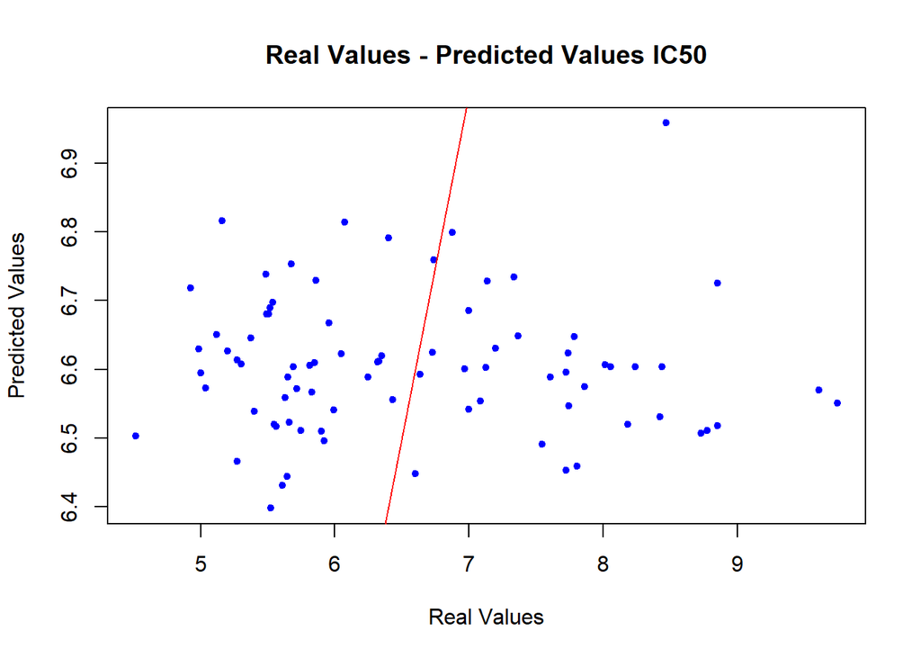

```r
pred = predict(lm.rges_ic50, newdata = rges.ic50.test)
plot(rges.ic50.test$IC50.value, pred, xlab = "Real Values", ylab = "Predicted Values", pch=20, col="blue", main = "Real Values - Predicted Values IC50")
abline(0, 1, col = "red")
```

It can be clearly seen, that the predicted values do not fit well with the real values. Normally, the blue dots should lay on the red line. This is an indication for a not convincing linear regression model.

##### Validity of the model

In order to indicate how well the model fit to the real data, the root mean square error (RMSE) can be computed.

```r
n = nrow(rges.ic50.train)
rmse.train = sqrt(1/n * sum(lm.rges_ic50$residuals^2))
n = nrow(rges.ic50.test)
residuals = rges.ic50.test$IC50.value - pred
rmse.test = sqrt(1/n * sum(residuals^2))
```

For the training set, following RMSE is obtained:

```
## [1] 1.225634
```

And for the test set:

```
## [1] 1.236037
```

The lower the RMSE, the better is the linear regression model. Normally, it should be next to zero. The obtained RMSE prove that the model does not fit very well to the real data.  
All in all, it can be concluded, that the RGES values do not have the potential to predict the drug sensitivity values. Only a very small proportion of the variablity can be explained by the model and the prediction results differ extremely from the real values.  
Due to these aspects, the univariate linear regression will be expanded. It will be checked, whether an inclusion of more variables could enhance the model.

## 2. Multiple Regression Model Cisplatin

### 2.1. Variabels: RGES and biomarkers

In order to obtain an enhanced model, a multiple regression for IC50 values of cisplatin is performed. The previously computed fold change values for the biomarkers for cisplatin are included. Then IC50 values are predicted with RGES values, as well as with genes which showed the most extreme and constant fold change values between treated and untreated patients.

### 2.1.2 Correlation between IC50, RGES and Biomarkers

To visualize the correlation pattern between Ic50 values, RGES and biomarkers, pairwise scatterplots, as well as a heatmap is produced.

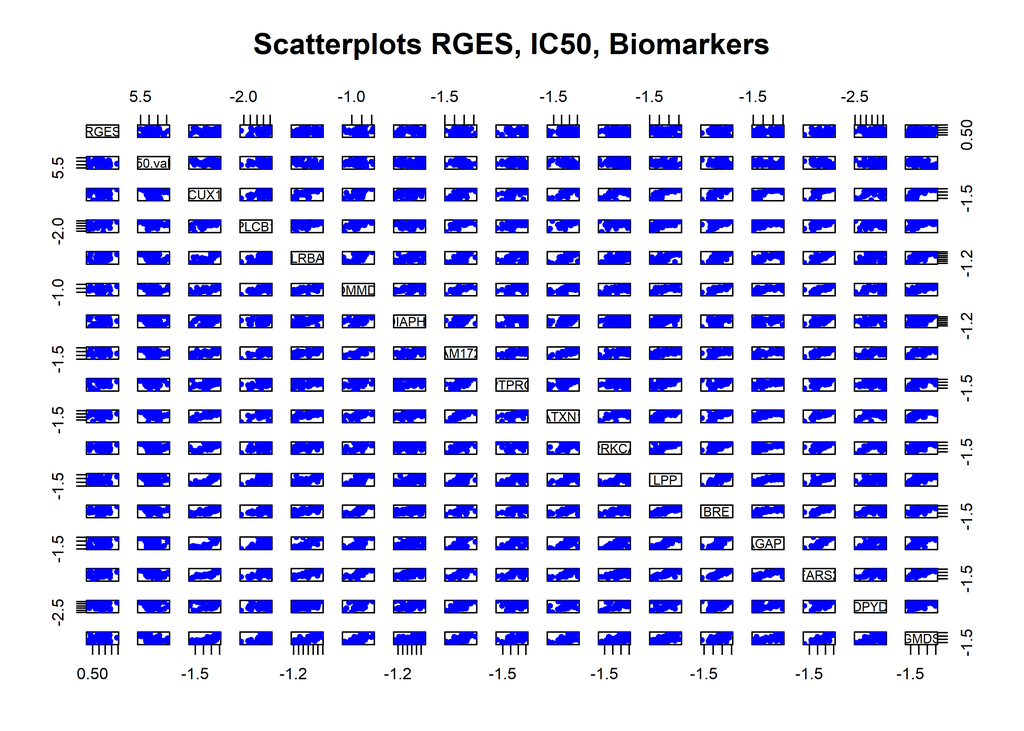

```r
pairs(rges.ic50.biomarkers, col = "blue", pch = 20, main = "Scatterplots RGES, IC50, Biomarkers")
```

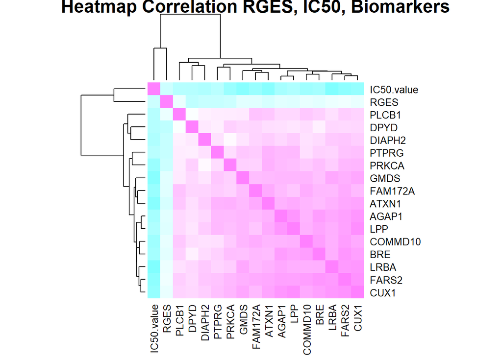

```r
cor.mat = cor(rges.ic50.biomarkers, method = "spearman")
heatmap(cor.mat, col = cm.colors(256), main = "Heatmap Correlation RGES, IC50, Biomarkers", symm = T)
```

It can be seen, that there in summary the correlation between biomarkers and IC50 values is quite low. One aspect, which can result in a problem, is the correlation between the variables. For example CUX1 and FARS2 show a strong correlation between eachother. Nevertheless, it will be performed a model with all variables.

### 2.1.3. Computation of multiple regression model

As before, to perform a multiple regression model, the data set has to be splitten up into two groups: a training set, which contains 45 random samples (~85% of the whole data set), and a test set out of the other values.

```r
train.multiple = sample(1:nrow(rges.ic50.biomarkers), 45)

train.set.multiple = rges.ic50.biomarkers[train.multiple, ]
test.set.multiple = rges.ic50.biomarkers[-train.multiple, ]
```

```r
model.multiple = lm(IC50.value ~ ., data = train.set.multiple)
```

```
##
## Call:
## lm(formula = IC50.value ~ ., data = train.set.multiple)
##
## Residuals:
##      Min       1Q   Median       3Q      Max
## -0.52420 -0.19008 -0.02342  0.20877  0.83961
##
## Coefficients:
##              Estimate Std. Error t value Pr(>|t|)
## (Intercept)  5.745484   0.680079   8.448 3.46e-09 ***
## RGES         0.027369   1.140439   0.024    0.981
## CUX1         0.132858   0.365521   0.363    0.719
## PLCB1        0.176030   0.212262   0.829    0.414
## LRBA        -0.580384   0.348590  -1.665    0.107
## COMMD10      0.534202   0.453078   1.179    0.248
## DIAPH2       0.078381   0.278012   0.282    0.780
## FAM172A     -0.161459   0.373136  -0.433    0.669
## PTPRG        0.120155   0.207517   0.579    0.567
## ATXN1       -0.152013   0.395174  -0.385    0.703
## PRKCA       -0.159013   0.253780  -0.627    0.536
## LPP         -0.043732   0.439897  -0.099    0.922
## BRE         -0.005278   0.438192  -0.012    0.990
## AGAP1        0.153267   0.283183   0.541    0.593
## FARS2       -0.205495   0.479503  -0.429    0.672
## DPYD         0.005604   0.132509   0.042    0.967
## GMDS        -0.332270   0.205520  -1.617    0.117
## ---
## Signif. codes:  0 '***' 0.001 '**' 0.01 '*' 0.05 '.' 0.1 ' ' 1
##
## Residual standard error: 0.3516 on 28 degrees of freedom
## Multiple R-squared:  0.4519, Adjusted R-squared:  0.1387
## F-statistic: 1.443 on 16 and 28 DF,  p-value: 0.1923
```

The output of the multiple regression model can be interpreted as follows: The R² value indicates, that ~15 % of the variability can be explained through the model. Comparing this value to the one of the univariate regression model, the explained variability is improved greatly. Nevertheless the F-statistic is next to 1, so that taking the mean as a prediction value is not really worse.  
In addition, the obtained p-values for some variables are quite high. This can be explained by the correlation between some of them.

In order to check again the residuals, a scatterplot of residuals versus fitted values, as well as a normal QQ plot of the residuals is produced.

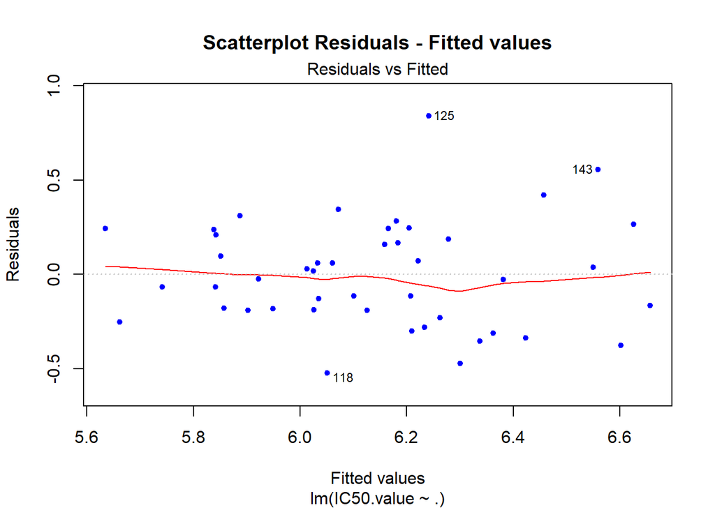

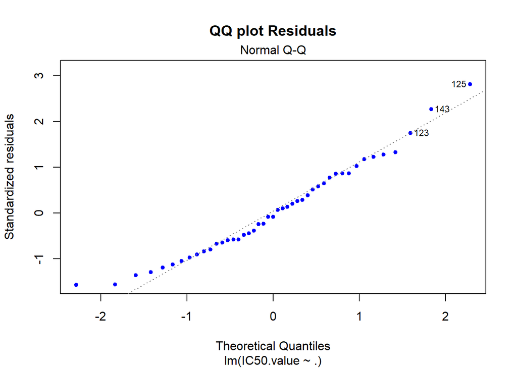

As expected, the residuals are distributed around the red line and therefore do not have non-linear patterns. The QQ plot illustrates, that the residuals are normally distributed.

In order to prove the correlation between residuals and variables, the correlation coefficient is computed. Correlation coefficient Residuals - Variables (RGES and biomarkers)

```
##                  [,1]
## RGES     9.348312e-17
## CUX1    -3.150675e-17
## PLCB1   -3.182496e-17
## LRBA    -1.430224e-17
## COMMD10 -2.769740e-17
## DIAPH2  -1.444174e-17
## FAM172A -3.702277e-17
## PTPRG   -6.952736e-17
## ATXN1   -2.984093e-17
## PRKCA   -3.906687e-17
## LPP     -3.922263e-17
## BRE     -8.522226e-17
## AGAP1   -3.412373e-17
## FARS2   -2.220430e-17
## DPYD    -2.329495e-17
## GMDS    -3.927243e-17
```

As the computation results in low coefficients, one can exclude a correlation between residuals and x.

### 2.1.4. Prediction of IC50 values cisplatin

At the end the multiple regression model is used to predict the values. The result is shown in a vector.

```r
predict.multiple = predict(model.multiple, newdata = test.set.multiple)
```

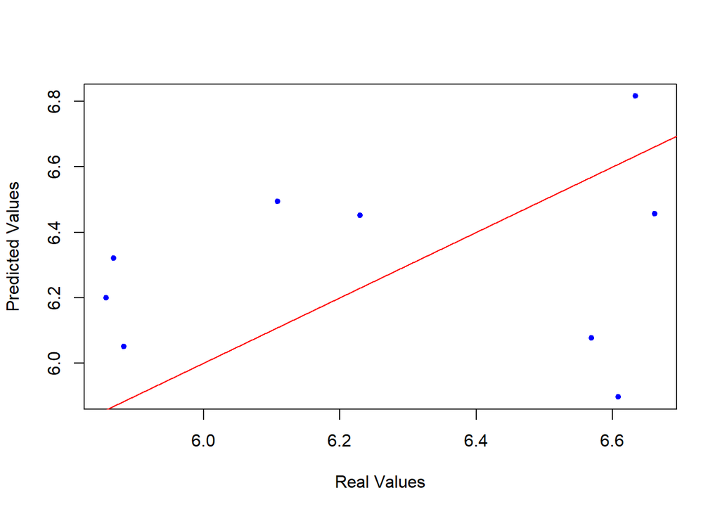

As the test set only contains 9 value, it is difficult to interpret the prediction. But in general the dots seem to be nearer by the red line.

Therefore it can be concluded, that the multiple regression model with RGES and biomarkers enhanced the model as well as the prediction.

#### Validity of the model

RMSE values for training and test set can be computed.

```r
n = nrow(train.set.multiple)
rmse.train = sqrt(1/n * sum(model.multiple$residuals^2))
n = nrow(test.set.multiple)
residuals = test.set.multiple$IC50.value - predict.multiple
rmse.test = sqrt(1/n * sum(residuals^2))
```

RMSE training set:

```
## [1] 0.2773662
```

RMSE test set:

```
## [1] 0.3903848
```

The RMSE values for training and test set are closer to zero. This indicates that the model does fit better to the real data than the univariate model did.

In summary, through an inclusion of further variables, the model could be improved. The explained variablilty, as well as the predicted values were enhanced.

Nevertheless the output showed high p values for some variables, which can be explained by a correlation between them.  
For that reason, the correlation between variables and drug sensitivity as well as the correlation between each explanatory variable is observed. Through a new model with variables, which show a more or less high correlation to IC50 as well as a low correlation to other explanatory variables the multiple regressioin model should be improved once again.

## 2.2. Multiple Regression Model Specific

### 2.2.1. Computation of the model with specific biomarkers

```r
model.multiple.biomarkers = lm(IC50.value ~ PTPRG + COMMD10 + GMDS + LRBA, data = train.set.multiple)
```

```
##
## Call:
## lm(formula = IC50.value ~ PTPRG + COMMD10 + GMDS + LRBA, data = train.set.multiple)
##
## Residuals:
##      Min       1Q   Median       3Q      Max
## -0.49449 -0.23702 -0.03994  0.18446  0.86489
##
## Coefficients:
##             Estimate Std. Error t value Pr(>|t|)
## (Intercept)  5.82111    0.11577  50.281   <2e-16 ***
## PTPRG        0.08561    0.12148   0.705   0.4851
## COMMD10      0.50917    0.21432   2.376   0.0224 *
## GMDS        -0.35795    0.16622  -2.153   0.0374 *
## LRBA        -0.59432    0.23271  -2.554   0.0146 *
## ---
## Signif. codes:  0 '***' 0.001 '**' 0.01 '*' 0.05 '.' 0.1 ' ' 1
##
## Residual standard error: 0.3118 on 40 degrees of freedom
## Multiple R-squared:  0.3845, Adjusted R-squared:  0.323
## F-statistic: 6.247 on 4 and 40 DF,  p-value: 0.0005289
```

The residuals were checked again:

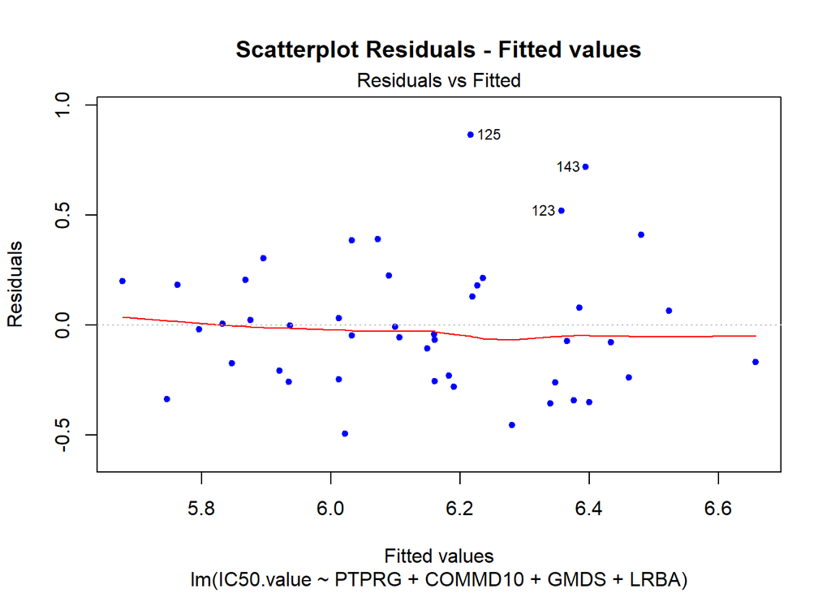

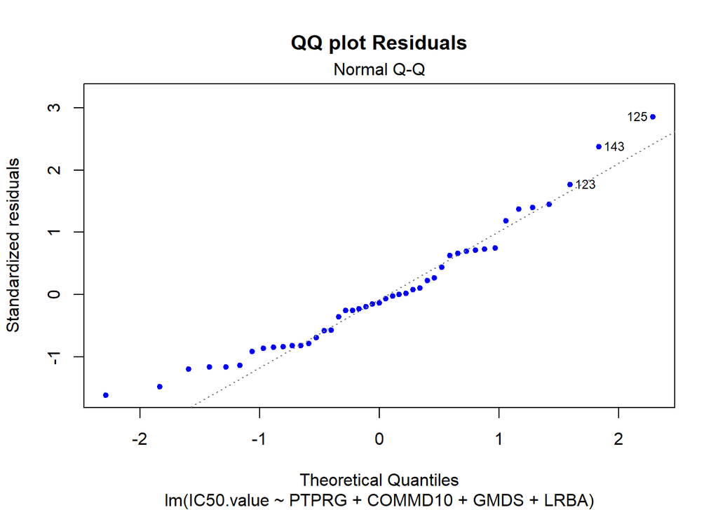

The residuals do not show non-linear relationships, as well as they are normally distributed.

### 2.2.2. Prediction of IC50 values

Now the model can be used to predict the data.

```r
predict.biomarkers = predict(model.multiple.biomarkers, newdata = test.set.multiple)
```

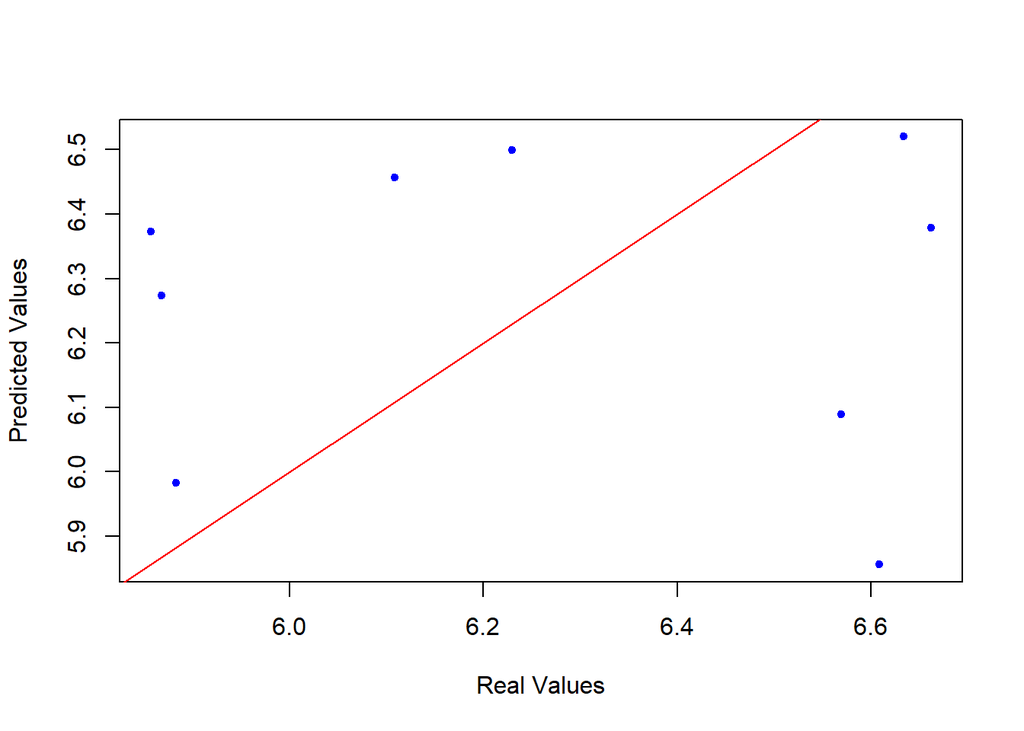

#### Validity of the model

To check the models validity, RMSE values for training and test set can be computed.

```r
n = nrow(train.set.multiple)
rmse.train = sqrt(1/n * sum(model.multiple.biomarkers$residuals^2))
n = nrow(test.set.multiple)
residuals = test.set.multiple$IC50.value - predict.biomarkers
rmse.test = sqrt(1/n * sum(residuals^2))
```

RMSE training set:

```
## [1] 0.2939209
```

RMSE test set

```
## [1] 0.4115993
```

## 2.3. Multiple Regression Model PCAs

### Variables: PCs

For a further enhancement of the multiple regression model, principle components instead of original variables were used. A barplot of the first principle component is illustrated.

```r
pca = prcomp(rges.ic50.biomarkers[, -2])
```

### 2.3.1. Analysation of PC1

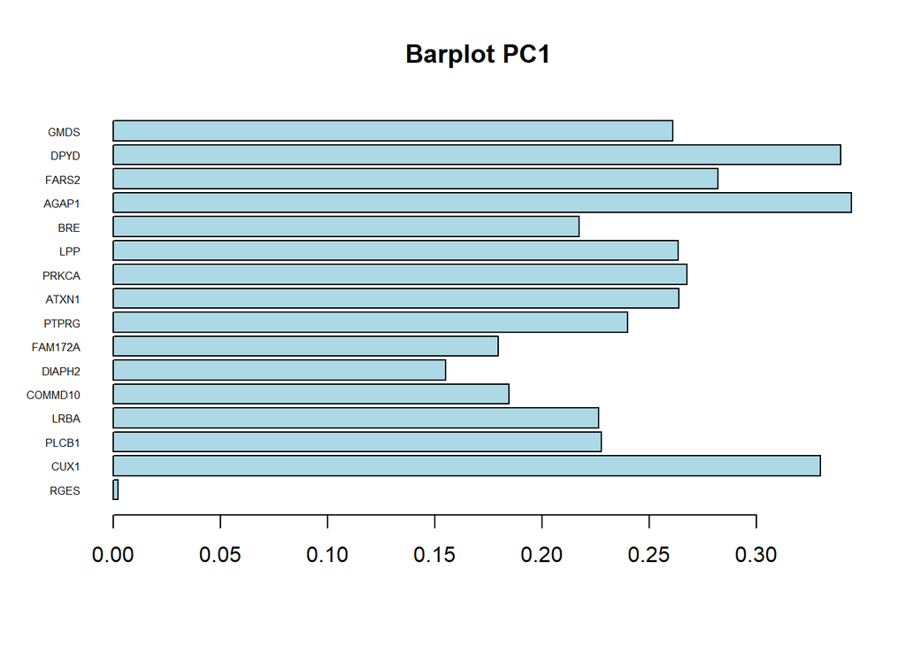

It can be seen, that PC 1 corresponds to variation out of every variable except RGES. The highest variation is explained through the biomarkers DPYP, AGAP1 and CUX1. First, it will be performed a multiple regression model including all PCs.

### 2.3.2. Computation of the Model

Finally, the multiple regression model can be computed.

```r
model.pca = lm(rges.ic50.biomarkers$IC50.value ~ pca$x)
```

```
##
## Call:
## lm(formula = rges.ic50.biomarkers$IC50.value ~ pca$x)
##
## Residuals:
##      Min       1Q   Median       3Q      Max
## -0.56308 -0.19300 -0.04965  0.17388  0.88668
##
## Coefficients:
##             Estimate Std. Error t value Pr(>|t|)
## (Intercept)  6.16100    0.04652 132.436  < 2e-16 ***
## pca$xPC1    -0.09584    0.03585  -2.673  0.01110 *
## pca$xPC2     0.01216    0.08241   0.148  0.88345
## pca$xPC3     0.11600    0.11783   0.984  0.33131
## pca$xPC4    -0.11117    0.12554  -0.886  0.38159
## pca$xPC5    -0.12315    0.14255  -0.864  0.39322
## pca$xPC6    -0.28050    0.16298  -1.721  0.09360 .
## pca$xPC7     0.54593    0.17744   3.077  0.00393 **
## pca$xPC8     0.08566    0.21629   0.396  0.69434
## pca$xPC9    -0.07730    0.23047  -0.335  0.73921
## pca$xPC10   -0.35371    0.25186  -1.404  0.16853
## pca$xPC11   -0.21252    0.27131  -0.783  0.43843
## pca$xPC12   -0.32139    0.34184  -0.940  0.35322
## pca$xPC13   -0.03028    0.40184  -0.075  0.94033
## pca$xPC14   -0.33777    0.45333  -0.745  0.46092
## pca$xPC15   -0.15076    0.53125  -0.284  0.77816
## pca$xPC16    0.45542    1.00883   0.451  0.65431
## ---
## Signif. codes:  0 '***' 0.001 '**' 0.01 '*' 0.05 '.' 0.1 ' ' 1
##
## Residual standard error: 0.3419 on 37 degrees of freedom
## Multiple R-squared:  0.419,  Adjusted R-squared:  0.1677
## F-statistic: 1.668 on 16 and 37 DF,  p-value: 0.09888
```

A R² value of ~0.16 is obtained. So through the model less variability is explained than through the model with specific biomarkers. As the F-statistic is next to one, it could not have been proved, that the computed model predicts the drug sensitivity values better than the mean would do. In addition some variables show a high p value. Therefore the correlation between the PCs will have to be checked.

The residuals were proved:

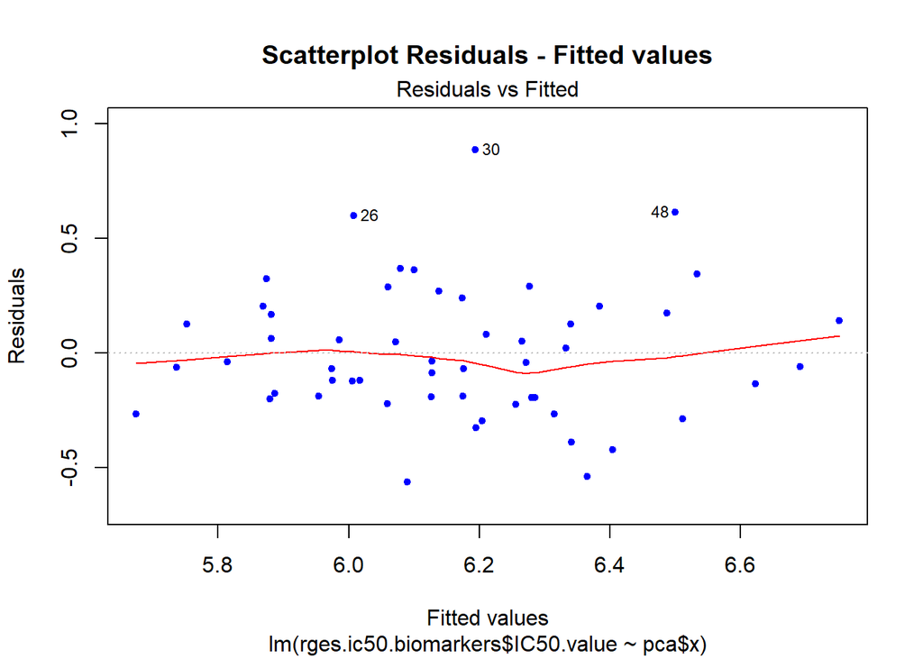

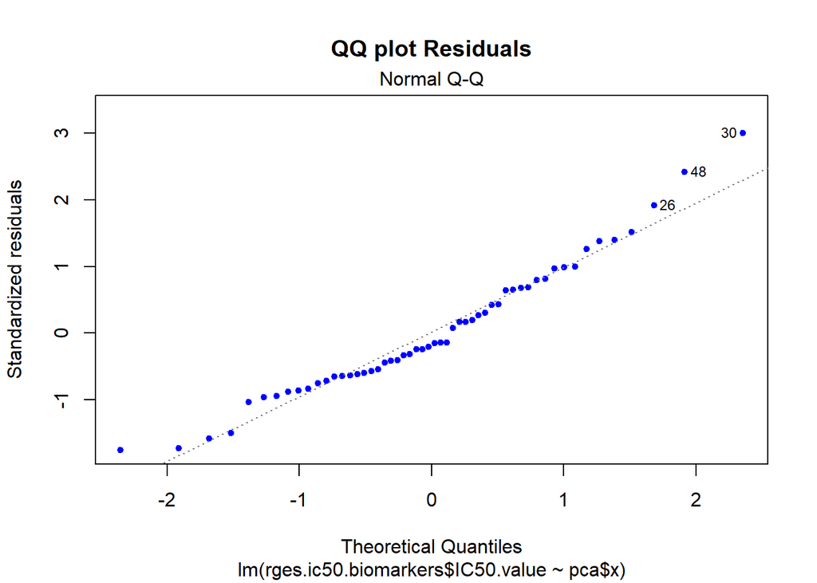

The two plots suggest, that the residuals are normally distributed, as well as they fit well to the real data.

### 2.3.3 Further ideas for an enhancement of the PC model

As high p values were obtained for some PCs, the correlation between them were proved.

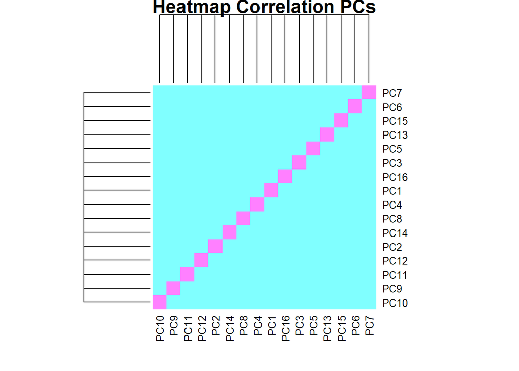

It can be clearly seen, that the high p values were not the result of a correlation between explanatory vaiables.

The model could be improved by a new choice of PCs. In order to look for the PCs which explain most of the data sets variance, an elbow plot was done.

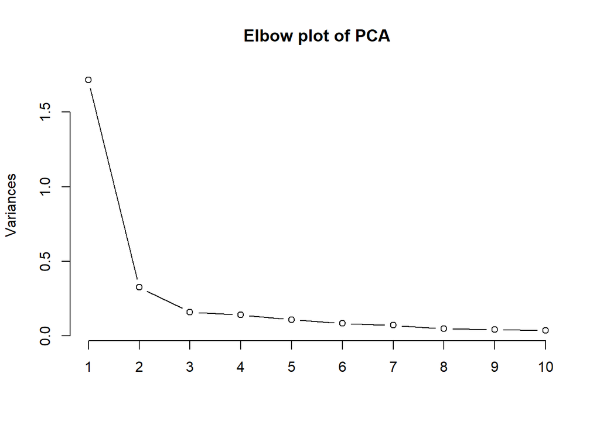

PC1 does contain most of the variance and PC2 still a bit more than the following ones. This plot suggests to redo the multiple regression model with these two PCs.